# 🚘 Car fuel consumption analysis and visualization on R

Arnon ‘Mud’ Sudyoddee

2024-03-09

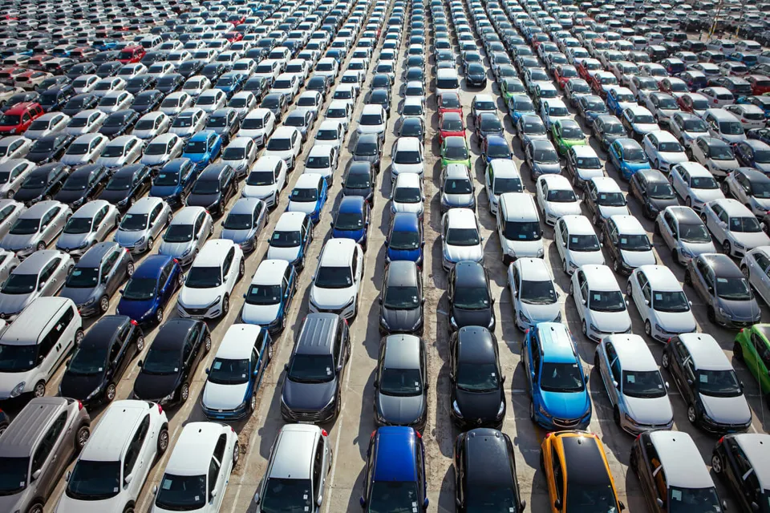

Car market, Fleet News

# 🚘 Intro

Greetings everyone, I welcome you to dive in analysis on fuel consumption dataset, ‘mpg’, the Rbase dataset

Library we’re using have tidyverse, dplyr, ggplot2, ggthemes, patchwork

```r
library(tidyverse)
library(ggthemes)
library(patchwork)
```

## 🚘 Preview data

```r
str(mpg)
```

```
## tibble [234 × 11] (S3: tbl_df/tbl/data.frame)
##  $ manufacturer: chr [1:234] "audi" "audi" "audi" "audi" ...
##  $ model       : chr [1:234] "a4" "a4" "a4" "a4" ...
##  $ displ       : num [1:234] 1.8 1.8 2 2 2.8 2.8 3.1 1.8 1.8 2 ...
##  $ year        : int [1:234] 1999 1999 2008 2008 1999 1999 2008 1999 1999 2008 ...
##  $ cyl         : int [1:234] 4 4 4 4 6 6 6 4 4 4 ...
##  $ trans       : chr [1:234] "auto(l5)" "manual(m5)" "manual(m6)" "auto(av)" ...
##  $ drv         : chr [1:234] "f" "f" "f" "f" ...
##  $ cty         : int [1:234] 18 21 20 21 16 18 18 18 16 20 ...
##  $ hwy         : int [1:234] 29 29 31 30 26 26 27 26 25 28 ...
##  $ fl          : chr [1:234] "p" "p" "p" "p" ...
##  $ class       : chr [1:234] "compact" "compact" "compact" "compact" ...
```

```r
glimpse(mpg)
```

```
## Rows: 234
## Columns: 11
## $ manufacturer <chr> "audi", "audi", "audi", "audi", "audi", "audi", "audi", "…
## $ model        <chr> "a4", "a4", "a4", "a4", "a4", "a4", "a4", "a4 quattro", "…
## $ displ        <dbl> 1.8, 1.8, 2.0, 2.0, 2.8, 2.8, 3.1, 1.8, 1.8, 2.0, 2.0, 2.…
## $ year         <int> 1999, 1999, 2008, 2008, 1999, 1999, 2008, 1999, 1999, 200…
## $ cyl          <int> 4, 4, 4, 4, 6, 6, 6, 4, 4, 4, 4, 6, 6, 6, 6, 6, 6, 8, 8, …
## $ trans        <chr> "auto(l5)", "manual(m5)", "manual(m6)", "auto(av)", "auto…
## $ drv          <chr> "f", "f", "f", "f", "f", "f", "f", "4", "4", "4", "4", "4…
## $ cty          <int> 18, 21, 20, 21, 16, 18, 18, 18, 16, 20, 19, 15, 17, 17, 1…
## $ hwy          <int> 29, 29, 31, 30, 26, 26, 27, 26, 25, 28, 27, 25, 25, 25, 2…
## $ fl           <chr> "p", "p", "p", "p", "p", "p", "p", "p", "p", "p", "p", "p…
## $ class        <chr> "compact", "compact", "compact", "compact", "compact", "c…
```

Let’s take a look on some interesting variables in dataset, manufacturer, model, displ, cty and class. I also noticed that year values seem suspicious. then i’ll check it.

```r
unique(mpg$year)
```

```
## [1] 1999 2008
```

Result show us ‘year’ column have only 2 values, ‘1999’ and ‘2008’. That is seem to be unuseful. So i’ll leave it be

### Check null value

next step we have to check if their any null value in mpg dataset.

```r
sum(is.na(mpg))
```

```
## [1] 0
```

Okay, that’s nice. The result seems to be no any null value in mpg. Let’s start asking some question in our dataset and visualize it.

## 🚘 1. Number of cars by manufacturer

### How many cars came from this manufacturer?

Let’s easily check number of cars in each manufacturer

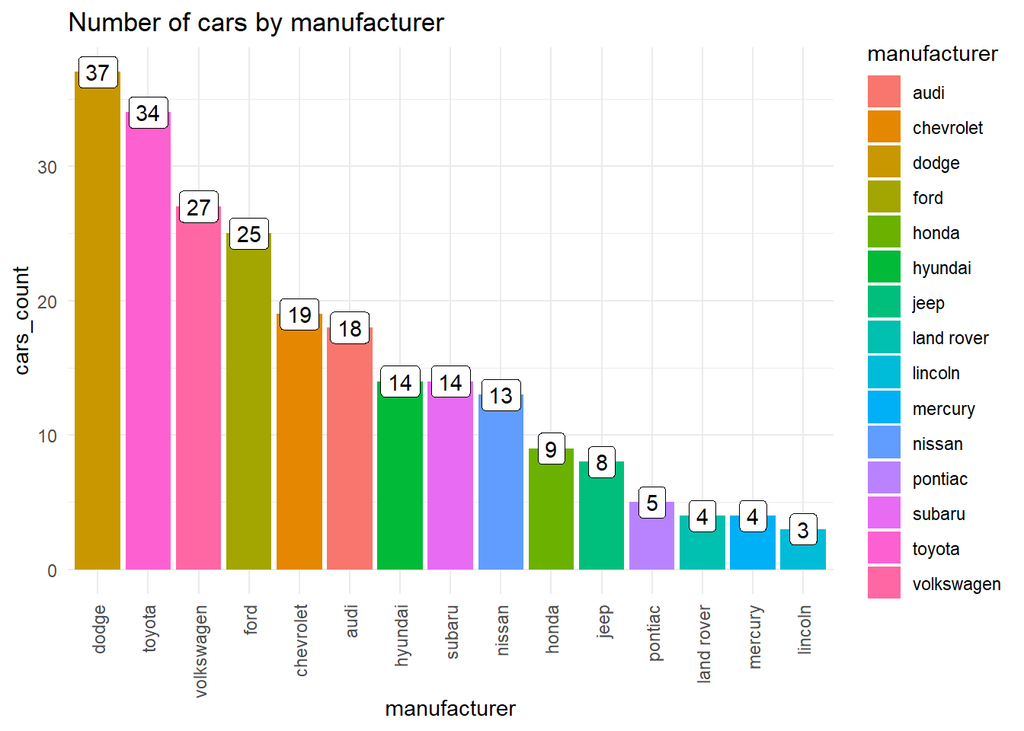

```r
mpg %>%
  group_by(manufacturer) %>%
  summarise(count = n()) %>%
  ggplot() +
  geom_col(aes(x = reorder(manufacturer , -count), y = count, fill = manufacturer)) +
  geom_label(aes(x = reorder(manufacturer , -count), y = count, label = count )) +
  labs(title = "Number of cars by manufacturer", x = "manufacturer", y = "cars_count") +
  theme_minimal() +
  theme(axis.text.x = element_text(angle = 90, vjust = 0.5, hjust=1))
```

Wow!. Dodge, Toyota, Volkswagen, Ford are the big-4 in Car market. because they have lots of car models. Let’s dive further.

## 🚘 2. Car Classes ratio across all manufacturer

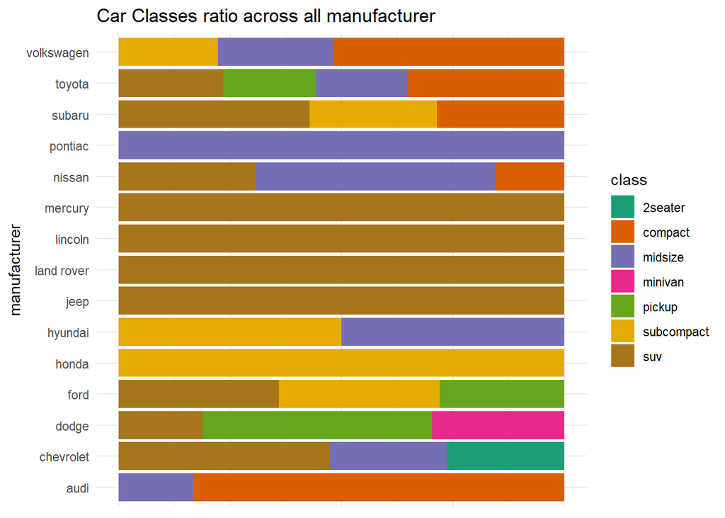

```r
ggplot(data = mpg, aes(y = manufacturer, fill = class)) +
  geom_bar(position = "fill") +
  scale_fill_brewer(palette = "Dark2") +
  labs(title = "Car Classes ratio across all manufacturer") +
  theme_minimal() +
  theme(axis.text.x = element_blank(),
        axis.title.x = element_blank())
```

## 🚘 3. Comparing between average city & highway m/gal across manufacturer

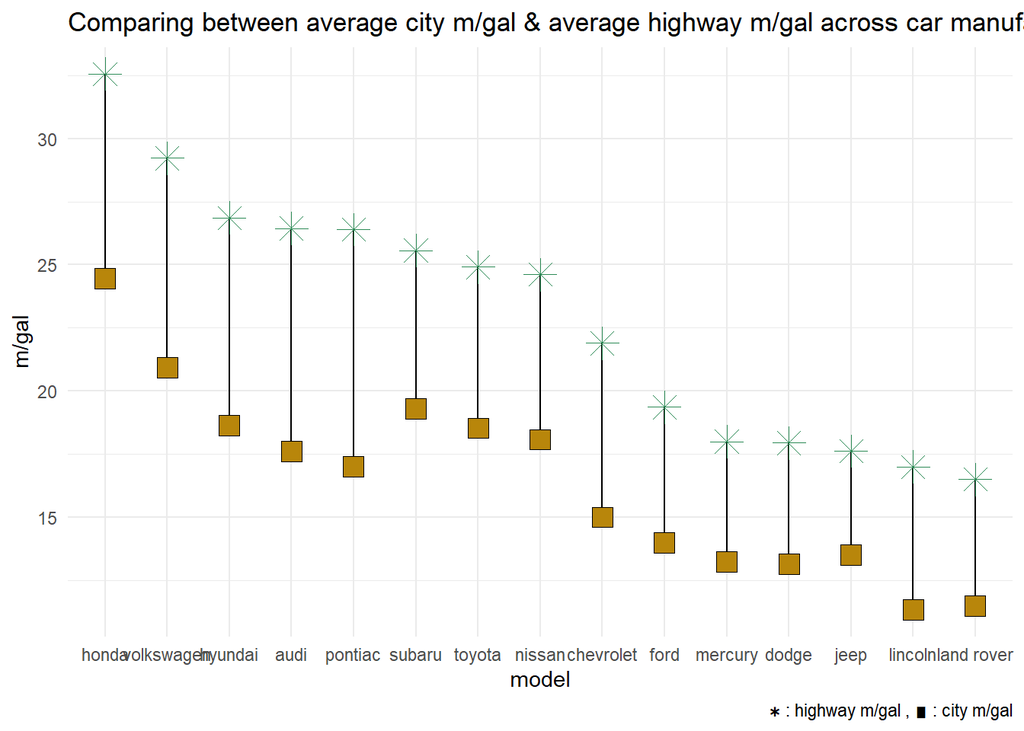

```r
mpg %>%
  group_by(manufacturer) %>%
  summarise(mean_cty = mean(cty),
            mean_hwy = mean(hwy)) %>%
  ggplot() +
  geom_linerange(aes(x = reorder(manufacturer, -mean_hwy),
                     y= mean_hwy ,
                     ymin = mean_cty,
                     ymax = mean_hwy))+
  geom_point(aes(x= manufacturer, y = mean_hwy),
             color = "seagreen", size = 5, shape = 8)+
  geom_point(aes(x= manufacturer, y = mean_cty),
            fill = "darkgoldenrod" , size = 5, shape = 22) +
  theme_minimal() +
  labs(title = "Comparing between average city m/gal & average highway m/gal across car manufacturer",
       y = "m/gal", x = "model", caption = "✱ : highway m/gal , ▮ : city m/gal")
```

The visualization surpised us that ‘Honda’ come to be #1 on the best fuel effiency manufacturer. Next we will look more deeper into car model.

## 🚘 4. Top 10 Car Models with the Best City and Highway Fuel Efficiency

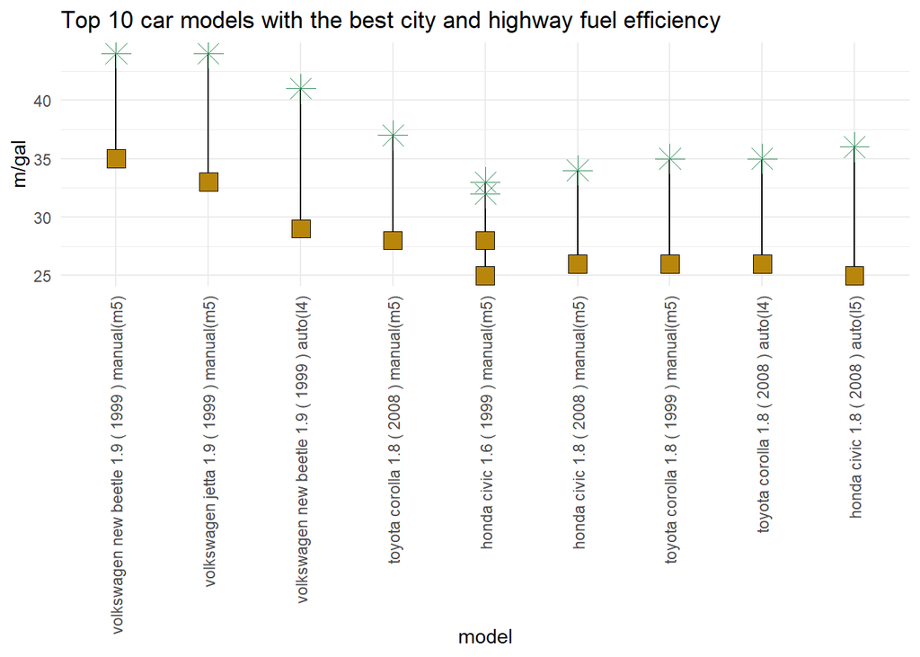

```r
mpg %>%
  rownames_to_column() %>%
  arrange(desc(cty)) %>%
  head(10) %>%
  mutate(model_name = paste(manufacturer, model, displ, "(",year,")", trans)) %>%
  ggplot() +
  geom_linerange(aes(x = reorder(model_name, -cty),
                     y= hwy ,
                     ymin = cty,
                     ymax = hwy))+
  geom_point(aes(x= model_name, y = hwy),
             color = "seagreen", size = 5, shape = 8)+
  geom_point(aes(x= model_name, y = cty),
            fill = "darkgoldenrod" , size = 5, shape = 22, ) +
  labs(title = "Top 10 car models with the best city and highway fuel efficiency",
       x = "model",
       y = "m/gal") +
  theme_minimal() +
  theme(axis.text.x = element_text(angle = 90, vjust = 0.5, hjust=1))
```

Even Volkswagen isn’t the best fuel efficiency on overall consumption. But top 3 of the most fuel efficiency car are all ‘Volkswagen’ came along with Toyota and Honda.

## 🚘 5. Comparing city fuel consumption between car classes and their engine displacement

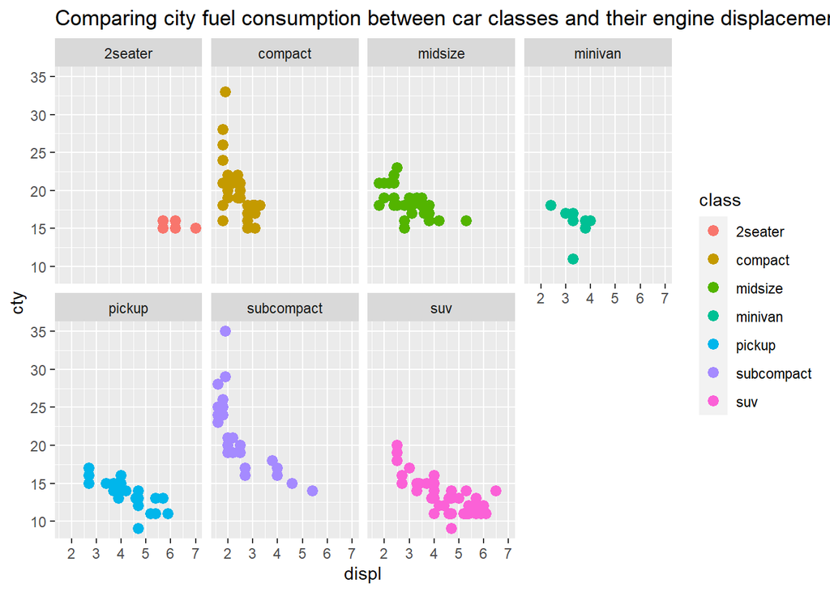

```r
mpg %>%
  ggplot(aes(x = displ, y = cty)) +
  geom_point(aes(color = class), size = 2.8) +
  labs(title = "Comparing city fuel consumption between car classes and their engine displacement") +
  facet_wrap(~class, 2)
```

We can examine the graph to identify which class has a higher dot, indicating lower fuel consumption. This suggests that compact and subcompact cars stand out as classes with good fuel efficiency.

## 🚘 6. Comparing Engine Displacement fuel consumption between city and highway paths

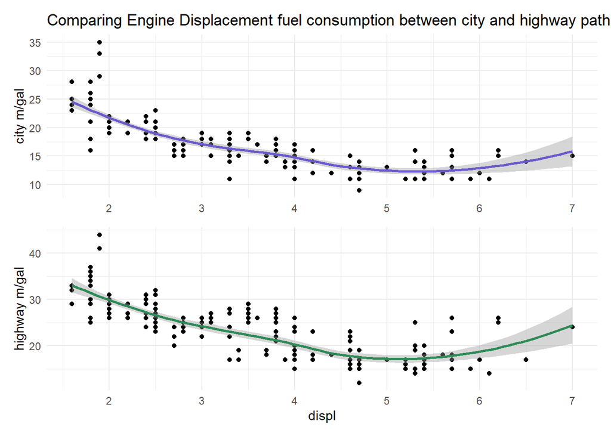

```r
cty_displ <- mpg %>%
  ggplot(aes(x = displ, y = cty)) +
  geom_point() +
  geom_smooth(color = "slateblue") +
  labs(title = "Comparing Engine Displacement fuel consumption between city and highway paths",
       y = "city m/gal") +
  theme_minimal()

hwy_displ <- mpg %>%
  ggplot(aes(x = displ, y = hwy)) +
  geom_point() +
  geom_smooth(color = "seagreen" )+
  labs(y = "highway m/gal") +
  theme_minimal()

cty_displ / hwy_displ + plot_layout(axis_titles = "collect")
```

Let’s delve into some details about car engine displacement. The trend lines from both graphs reveal that a lower engine displacement indicates that the car will have lower fuel consumption.

## 🔑 Key Takeaways

### 1. Compact and Subcompact cars can rely on good fuel efficiency.

### 2. Lower engine displacement indicates that the car will have lower fuel consumption.

## ————————————————————————————————-

## 😎 Feel free to reach me

Thanks a bunch 🙏 for checking out my analysis! I appreciate you taking the time to read through it. Your interest means a lot! If you have any questions or would like to discuss further, feel free to contact me here. Looking forward to connecting with you